# Predicting flight delays

## Seasonal Analysis

### Weekday Distribution

In the first plot on the left in blue, which focus on the distribution of **delayed** flights, delays are more likely to happen on Mondays, Thursdays and Fridays.

In the second plot on the right in grey, which plot the distribution of **all** flights, weekdays have the same number of flights, weekends are more quiet

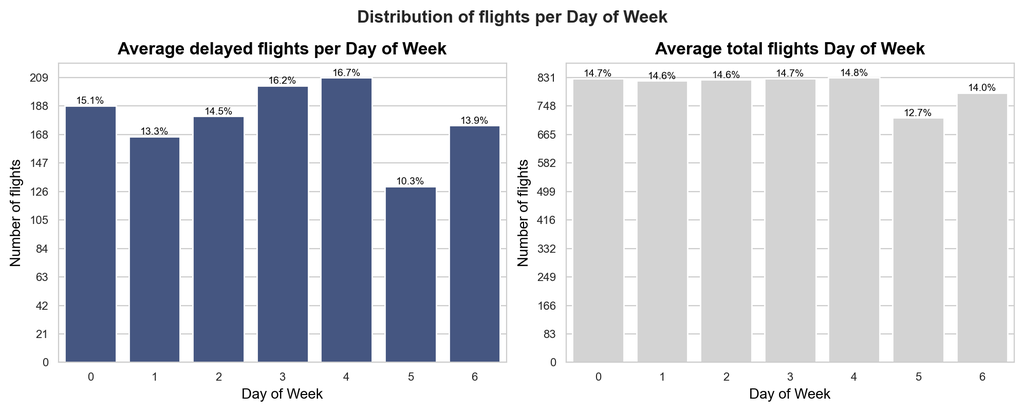

## Seasonal Analysis

### Time of day Distribution

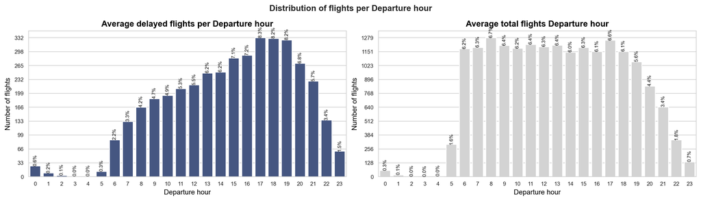

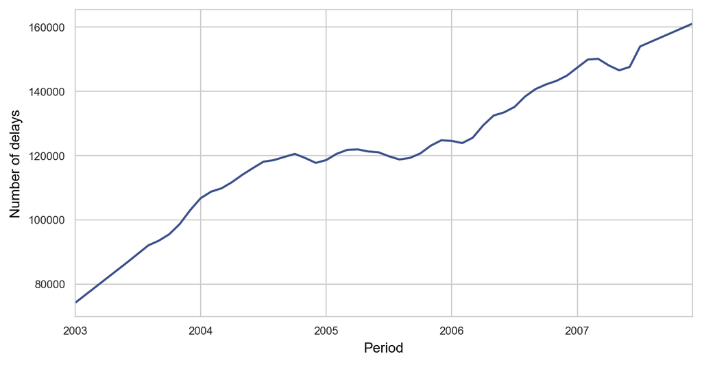

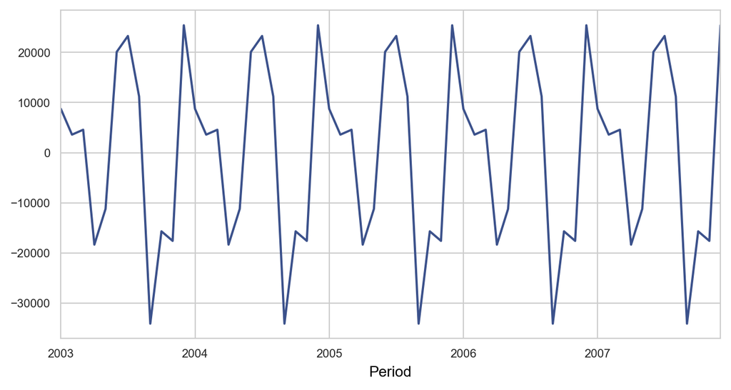

## Seasonal Analysis

### When is the best time of year/day of week/time of day to fly to minimise delays?

- Delays decrease in spring/autumn months.
- Airports are more busy during peak periods, even though number of flights do not increase. This might be due to an increase in passengers on fully booked flights, thus more passengers in airports